# Adding fused lasso as a user-defined function in caret

YAN Ting Hin

# 1 README

The official `caret` documentation is one of the most comphrehensive I have seen so you should always read that first! See: https://topepo.github.io/caret/

# 2 TL;DR

`caret` allows you to write your own programme but it is hard to start from scratch. This demo shows you how you can retreive the code of an existing model and take bits and pieces from it to introduce a new function to `caret`.

# 3 Demo

In this demo, I am going to add fused lasso to `caret`. There are tons of packages that do fused lasso but I only managed to wrap my head around 2 of them: namely: `genlasso` and `penalized`.

For now I will focus on `genlasso`.

## 3.1 The boring bits

### 3.1.1 Libraries

```r
library(midasr)
library(caret)
library(tidyr)
library(dplyr)
library(parallel)
library(doParallel)
library(purrr)

# 2 packages in R that can do fused lasso which I understand
library(genlasso)
library(penalized)
```

### 3.1.2 What is fused lasso?

Tibshirani (2005): The fussed lasso minimises this criterion:

$$\frac{1}{2}\sum_{t=1}^T(y_t - x_t'\beta)^2 + \lambda\sum_{i = 1}^{N-1}|\beta_i - \beta_{i+1}| + \gamma\lambda\sum_{i=1}^N|\beta_i|$$

So there are 2 tuning parameters namely $\lambda$ and $\gamma$.

## 3.2 Existing models

Out of the box `caret` includes quite a few machine learning models such as `rf`, `ranger`, `gbm` and `glmnet`. There are 2 ways to get the codes of these included models:

1. Go to the github page of `caret`, look under the folder called “models”: https://github.com/topepo/caret
2. Make use of the `getModelInfo` function that comes with `caret`: See below

I am working on fused lasso, of course the most relevant model for me is `glmnet`.

```r
glmnetModelInfo <- getModelInfo(model = "glmnet", regex = FALSE)[[1]]; names(glmnetModelInfo)
```

```
##  [1] "label"      "library"    "type"       "parameters" "grid"
##  [6] "loop"       "fit"        "predict"    "prob"       "predictors"
## [11] "varImp"     "levels"     "tags"       "sort"       "trim"
```

So a model in `caret` is nothing just a **named list** albeit quite a long one. While there are quite a few things going on, only these are compulsory:

1. library
2. type
3. parameters
4. grid
5. fit
6. predict
7. prob (note: for classification problems only)
8. sort

And in this specific demo, I will also define one extra optional element:

9. loop

Other parts are merely bells and whistles and well…ain’t nobody got time for that.

## 3.3 Changing bits and pieces

### 3.3.1 library, type, parameters

These are strings that are doing nothing but giving users information about the model.

```r
glmnetModelInfo[names(glmnetModelInfo) %in% c("library", "type", "parameters")]
```

```
## $library
## [1] "glmnet" "Matrix"
##
## $type
## [1] "Regression"     "Classification"
##
## $parameters
##   parameter   class                    label
## 1     alpha numeric        Mixing Percentage
## 2    lambda numeric Regularization Parameter
```

Let’s replicate that structure for fused lasso

```r
fused_lasso <- list(

  library = "genlasso",
  type = "Regression",
  parameters = data.frame(parameter = c('lambda', 'gamma'),
                          class = c("numeric", "numeric"),
                          label = c('Fusion Penalty', 'Sparsity Loading'))
  )
```

### 3.3.2 grid

If you are familiar with `caret`, you will know that you can tune a model by either:

1. Tell `caret` to tune how many models via the parameter `tuneLength` (which is a grid search under the hood)
2. Ask `caret` to do a random search (See https://topepo.github.io/caret/random-hyperparameter-search.html)
3. You supply a grid and ask `caret` to search through all of them (keywords: `expand.grid`)

The `grid` element deals with the first 2 methods.

```r
glmnetModelInfo[names(glmnetModelInfo) %in% c("grid")]
```

```
## $grid
## function (x, y, len = NULL, search = "grid")
## {
##     if (search == "grid") {
##         numLev <- if (is.character(y) | is.factor(y))
##             length(levels(y))
##         else NA
##         if (!is.na(numLev)) {
##             fam <- ifelse(numLev > 2, "multinomial", "binomial")
##         }
##         else fam <- "gaussian"
##         init <- glmnet::glmnet(Matrix::as.matrix(x), y, family = fam,
##             nlambda = len + 2, alpha = 0.5)
##         lambda <- unique(init$lambda)
##         lambda <- lambda[-c(1, length(lambda))]
##         lambda <- lambda[1:min(length(lambda), len)]
##         out <- expand.grid(alpha = seq(0.1, 1, length = len),
##             lambda = lambda)
##     }
##     else {
##         out <- data.frame(alpha = runif(len, min = 0, 1), lambda = 2^runif(len,
##             min = -10, 3))
##     }
##     out
## }
```

It looks horrible but all you need to care is that the object `out` takes different forms depending on whether the user specifies `tuneLength` or a random search; and if `tuneLength` is chosen, then you set up a grid via `expand.grid` like so:

```r
out <- expand.grid(alpha = seq(0.1, 1, length = len), lambda = lambda)
```

or else you do a random search via `runif` like so:

```r
out <- data.frame(alpha = runif(len, min = 0, 1), lambda = 2^runif(len, min = -10, 3))
```

Notice that the parameter `len` is specified by the user when he/she specifies `tuneLength` in `trainControl`.

With this in mind, in the fused lasso context, I can cut down the complexity remarkably and just do this:

```r
fused_lasso$grid <- function(x, y, len = NULL, search = "grid") {

  # grid search
  if(search == "grid") {

    grid <- expand.grid(lambda = exp(-seq(1, 10, length = len)), gamma = seq(1,5,1))

    } else {

      grid <- expand.grid(lambda = 2^runif(len, min = -10, max = 3), gamma = seq(1,5,1))}

  return(grid)
}
```

*“Are these parameters sensible?”* one might ask. Probably not but then for me I am going to supply my own tuning parameter grid and not rely on `tuneLength` or random search anyway, so I might as well just leave them as they are and focus on more important stuff.

### 3.3.3 fit (important!)

This is the main workhorse of the `caret` model where you specify what model to fit!

Let’s first start by looking at how `glmnet` does it.

```r
glmnetModelInfo[names(glmnetModelInfo) %in% c("fit")]
```

```
## $fit
## function (x, y, wts, param, lev, last, classProbs, ...)
## {
##     numLev <- if (is.character(y) | is.factor(y))
##         length(levels(y))
##     else NA
##     theDots <- list(...)
##     if (all(names(theDots) != "family")) {
##         if (!is.na(numLev)) {
##             fam <- ifelse(numLev > 2, "multinomial", "binomial")
##         }
##         else fam <- "gaussian"
##         theDots$family <- fam
##     }
##     if (!is.null(wts))
##         theDots$weights <- wts
##     if (!(class(x)[1] %in% c("matrix", "sparseMatrix")))
##         x <- Matrix::as.matrix(x)
##     modelArgs <- c(list(x = x, y = y, alpha = param$alpha), theDots)
##     out <- do.call(glmnet::glmnet, modelArgs)
##     if (!is.na(param$lambda[1]))
##         out$lambdaOpt <- param$lambda[1]
##     out
## }
```

So `fit` is nothing but a function that takes a specific set of arguments. For a thorough description of what each argument is and does, see: https://topepo.github.io/caret/using-your-own-model-in-train.html

As for all other elements in `caret`, if you want to understand what the code is doing, it is easier to **start at the end** and look for the object called `out`. In fact, the main functionality of `glmnet` comes from these few lines of code:

```r
modelArgs <- c(list(x = x, y = y, alpha = param$alpha), theDots)
out <- do.call(glmnet::glmnet, modelArgs)
```

where the `param` argument contains the current tuning parameter value.

So it should be quite easy to replicate that for fused lasso:

```r
fused_lasso$fit <- function(x, y, wts, param, lev, last, classProbs, ...) {

                      # all other options
                      theDots <- list(...)

                      # make sure your x variable is a matrix
                      if(!(class(x)[1] %in% c("matrix", "sparseMatrix")))
                        x <- Matrix::as.matrix(x)

                      modelArgs <- c(list(X = x, y = y,
                                          gamma = param$gamma), theDots)

                      # this will run the model for a series of lambda values
                      out <- do.call(genlasso::fusedlasso1d, modelArgs)

                      # finally add lambda to the list of objects
                      if(!is.na(param$lambda[1])) out$lambdaOpt <- param$lambda[1]

                      return(out)

}
```

As you can see, it is almost identical to the setup of `glmnet` but with 4 tweaks:

1. I don’t care about classifcation problems so I just ignore the argument `lev`
2. I don’t allow for instance weights so no `wts`
3. I just substituted out `alpha` for `gamma`
4. I just substituted out `glmnet::glmnet` for `genlasso::fusedlasso1d`

and that’s about it.

For those curious minds out there, you may be wondering why on earth there is a mysterious line of code that says this:

```r
if(!is.na(param$lambda[1])) out$lambdaOpt <- param$lambda[1]
```

My honest answer is that since it is there in `glmnet` so I retained it in my `fussed_lasso` fucntion.

If you are not happy with that answer, I will also offer my intuition: when you run `glmnet` or `fusedlasso1d`, the function will automatically calculate $\hat\beta$’s corresponding to a series of $\lambda$ values so a `fit` object is not associated with a single $\lambda$ value but a series of $\lambda$ value**s** (and you have more than 1 fit object because you are looping through a series of tuning parameters, in this case $\gamma$).

But for the subsequent `predict` element `caret` requires us to define, it calls back from the `fit` element for a single $\lambda$ value so we have to include it in the `fit` element.

Not the clearest explanation I know but hopefully it will become clearer after you go through the next section.

### 3.3.4 predict and loop (difficult!)

```r
glmnetModelInfo[names(glmnetModelInfo) %in% c("predict")]
```

```
## $predict
## function (modelFit, newdata, submodels = NULL)
## {
##     if (!is.matrix(newdata))
##         newdata <- Matrix::as.matrix(newdata)
##     if (length(modelFit$obsLevels) < 2) {
##         out <- predict(modelFit, newdata, s = modelFit$lambdaOpt)
##     }
##     else {
##         out <- predict(modelFit, newdata, s = modelFit$lambdaOpt,
##             type = "class")
##     }
##     if (is.matrix(out))
##         out <- out[, 1]
##     if (!is.null(submodels)) {
##         if (length(modelFit$obsLevels) < 2) {
##             tmp <- as.list(as.data.frame(predict(modelFit, newdata,
##                 s = submodels$lambda)))
##         }
##         else {
##             tmp <- predict(modelFit, newdata, s = submodels$lambda,
##                 type = "class")
##             tmp <- if (is.matrix(tmp))
##                 as.data.frame(tmp, stringsAsFactors = FALSE)
##             else as.character(tmp)
##             tmp <- as.list(tmp)
##         }
##         out <- c(list(out), tmp)
##     }
##     out
## }
```

If you just focus on line 6, you can see that all this `predict` element is doing is simply this:

```r
out <- predict(modelFit, newdata, s = modelFit$lambdaOpt)
```

where the `lambdaOpt` value we defined earlier in the `fit` element is being used here! That’s why we had to have it defined in the `fit` element.

Then there is something called `submodels` on line 14. This mysterious term actually comes from another `caret` element namely `loop`:

```r
glmnetModelInfo[names(glmnetModelInfo) %in% c("loop")]
```

```
## $loop
## function (grid)
## {
##     alph <- unique(grid$alpha)
##     loop <- data.frame(alpha = alph)
##     loop$lambda <- NA
##     submodels <- vector(mode = "list", length = length(alph))
##     for (i in seq(along = alph)) {
##         np <- grid[grid$alpha == alph[i], "lambda"]
##         loop$lambda[loop$alpha == alph[i]] <- np[which.max(np)]
##         submodels[[i]] <- data.frame(lambda = np[-which.max(np)])
##     }
##     list(loop = loop, submodels = submodels)
## }
```

`submodels` are only relevant for certain functions. If you recall what I said about `glmnet` and `fusedlasso1d` in the previous section, the `fit` object resulted from these 2 models is associated with a series of $\lambda$ values so when you are tuning the model for different values of $\lambda$, you do not need to re-fit the model again.

Consider the following example, suppose that I am tuning my fused lasso model using the following grid:

```r
example_grid <- expand.grid(gamma = 1, lambda = seq(1,5,1)); example_grid
```

```
##   gamma lambda
## 1     1      1
## 2     1      2
## 3     1      3
## 4     1      4
## 5     1      5
```

I can of course fit 5 models where each model corresponds to a row of the grid (which is very time consuming btw) but it’s better if I just fit `fusedlasso1d` once setting $\gamma$ and $\lambda$ both to 1, then derive predictions associated with the remaining 4 $\lambda$ values (row 2 to 5) as they also have $\gamma$ set equal to 1 - these 4 models are precisely what `caret` calls `submodels`.

To make things even more confusing, in the context of `glmnet`, `caret` calls `alpha` a “fixed” parameter while calling `lambda` a “sequential” parameter. And in the case of `fusedlasso1d`, `gamma` is “fixed” and `lambda` is “sequential”.

If you need more examples to get your head round this, see https://topepo.github.io/caret/using-your-own-model-in-train.html#illustrative-example-2-something-more-complicated---logitboost.

```r
# defining submodels
fused_lasso$loop <- function(grid) {

  gamma <- unique(grid$gamma)
  loop <- data.frame(gamma = gamma)
  loop$lambda <- NA
  submodels <- vector(mode = "list", length = length(gamma))

  for(i in seq(along = gamma)) {

    # obtain all lambda values for a given gamma
    np <- grid[grid$gamma == gamma[i], "lambda"]

    # assign the max lambda (for a given gamma) as THE lambda
    # actually it doesn't have to be the biggest lambda
    # all you need to make sure is that you have a way to isolate a particular lambda
    loop$lambda[loop$gamma == gamma[i]] <- np[which.max(np)]

    # all other lambdas - treat them as submodels
    submodels[[i]] <- data.frame(lambda = np[-which.max(np)])

  }

  # why make a list? because that's how caret likes it!
  list(loop = loop, submodels = submodels)

}
```

```r
fused_lasso$predict <- function(modelFit, newdata, submodels = NULL) {

  # make sure your newdata is matrix form
  if(!is.matrix(newdata)) newdata <- Matrix::as.matrix(newdata)

  # see https://rdrr.io/github/glmgen/genlasso/man/predict.genlasso.html
  out <- predict(object = modelFit, Xnew = newdata, lambda = modelFit$lambdaOpt)$fit

  # or you can do it the old school way
  #out <- newdata %*% coef(modelFit, lambda = modelFit$lambdaOpt)$beta

  # extract the first column
  if(is.matrix(out)) out <- out[,1]

  # derive predictions for all other lambda values
  if(!is.null(submodels)) {

    tmp <- as.list(as.data.frame(predict(object = modelFit,
                                         Xnew = newdata, lambda = submodels$lambda)$fit))

    out <- c(list(out), tmp)

  }

  return(out)

}
```

### 3.3.5 prob and sort

```r
glmnetModelInfo[names(glmnetModelInfo) %in% c("prob", "sort")]
```

```
## $prob
## function (modelFit, newdata, submodels = NULL)
## {
##     obsLevels <- if ("classnames" %in% names(modelFit))
##         modelFit$classnames
##     else NULL
##     probs <- predict(modelFit, Matrix::as.matrix(newdata), s = modelFit$lambdaOpt,
##         type = "response")
##     if (length(obsLevels) == 2) {
##         probs <- as.vector(probs)
##         probs <- as.data.frame(cbind(1 - probs, probs))
##         colnames(probs) <- modelFit$obsLevels
##     }
##     else {
##         probs <- as.data.frame(probs[, , 1, drop = FALSE])
##         names(probs) <- modelFit$obsLevels
##     }
##     if (!is.null(submodels)) {
##         tmp <- predict(modelFit, Matrix::as.matrix(newdata),
##             s = submodels$lambda, type = "response")
##         if (length(obsLevels) == 2) {
##             tmp <- as.list(as.data.frame(tmp))
##             tmp <- lapply(tmp, function(x, lev) {
##                 x <- as.vector(x)
##                 tmp <- data.frame(1 - x, x)
##                 names(tmp) <- lev
##                 tmp
##             }, lev = modelFit$obsLevels)
##         }
##         else tmp <- apply(tmp, 3, function(x) data.frame(x))
##         probs <- if (is.list(tmp))
##             c(list(probs), tmp)
##         else list(probs, tmp)
##     }
##     probs
## }
##
## $sort
## function (x)
## x[order(-x$lambda, x$alpha), ]
```

As you can see, `sort` only affects how results are shown so let’s keep that as is for my new function:

```r
# because I am lazy
fused_lasso$prob <- NULL

fused_lasso$sort <- function(x) x[order(-x$lambda, x$gamma),]
```

## 3.4 Putting it all together

```r
fused_lasso <- list(library = "genlasso",

                    type = "Regression",

                    parameters = data.frame(parameter = c('lambda', 'gamma'),
                                          class = c("numeric", "numeric"),
                                          label = c('Fusion Penalty', 'Sparsity Loading')),

                    grid = function(x, y, len = NULL, search = "grid") {

                      if(search == "grid") {

                        grid <- expand.grid(lambda = exp(-seq(1, 10, length = len)),
                                            gamma = seq(1,5,1))

                        } else {grid <- expand.grid(lambda = 2^runif(len, min = -10, max = 3),
                                          gamma = c(1,2))}

                      return(grid)},

                    loop = function(grid) {

                      gamma <- unique(grid$gamma)
                      loop <- data.frame(gamma = gamma)
                      loop$lambda <- NA
                      submodels <- vector(mode = "list", length = length(gamma))

                      for(i in seq(along = gamma)) {

                        np <- grid[grid$gamma == gamma[i], "lambda"]

                        loop$lambda[loop$gamma == gamma[i]] <- np[which.max(np)]

                        submodels[[i]] <- data.frame(lambda = np[-which.max(np)])

                      }

                      list(loop = loop, submodels = submodels)

                    },

                    fit = function(x, y, wts, param, lev, last, classProbs, ...) {

                      theDots <- list(...)

                      if(!(class(x)[1] %in% c("matrix", "sparseMatrix")))
                        x <- Matrix::as.matrix(x)

                      modelArgs <- c(list(X = x, y = y,
                                          gamma = param$gamma), theDots)

                      out <- do.call(genlasso::fusedlasso1d, modelArgs)

                      if(!is.na(param$lambda[1])) out$lambdaOpt <- param$lambda[1]


                      return(out)

                    },

                    predict = function(modelFit, newdata, submodels = NULL) {

                      if(!is.matrix(newdata)) newdata <- Matrix::as.matrix(newdata)


                      out <- predict(object = modelFit, Xnew = newdata, lambda = modelFit$lambdaOpt)$fit

                      if(is.matrix(out)) out <- out[,1]

                      if(!is.null(submodels)) {


                        tmp <- as.list(as.data.frame(predict(object = modelFit,
                                                             Xnew = newdata, lambda = submodels$lambda)$fit))
                        out <- c(list(out), tmp)

                      }

                      return(out)

                    },

                    prob = NULL,

                    sort = function(x) x[order(-x$lambda, x$gamma),]
)
```

# 4 Test

Let’s test if the `fused_lasso` function is doing what you expect it to do. To do that, I will apply fused lasso via the newly constructed `fused_lasso` function within the `caret` framework and compare that to the results I get when calculating by hand.

## 4.1 Data

Let’s generate some data.

```r
set.seed(2019)

# 10 variables, 1000 observations
n = 1000
p = 10

X = matrix(rnorm(n*p), ncol = p)

# only the first 2 variables matters, others are purely noise
y = X[,1] + X[,2] + rnorm(n)

df <- cbind.data.frame(y, X)
colnames(df) <- c("y", paste0("X_", seq(1,10,1)))
```

## 4.2 K-folds

Create 5 custom folds which are hold-out samples for evaluating model performance.

```r
folds <- createFolds(y, 5, returnTrain = TRUE); length(folds)
```

```
## [1] 5
```

## 4.3 `fussed_lasso` under `caret`

```r
start_time1 <- Sys.time()

fitControl <- trainControl(method = "cv",
                           number = 5,
                           index = folds, # specified hold-out samples for comparison w/ by-hand
                           savePredictions = TRUE)

check_caret <- train(y ~ ., df,
                     method = fused_lasso,
                     tuneLength = 5, # notice here the default grid search is a bit silly
                                     # for testing only! dont use it in production!
                     trControl = fitControl)

end_time1 <- Sys.time()

caret_speed <- end_time1 - start_time1
```

## 4.4 Fused lasso by hand

```r
start_time2 <- Sys.time()

# re-arrange training data into a list according to "fold" indices
train_test_data_list <- lapply(c(1:length(folds)), function(index){

  # define training index
  train_index = folds[[index]]

  # training data as dataframe
  training = df[train_index, ]

  y_train = training$y %>% as.numeric(.)
  X_train = training[,-1] %>% as.matrix(.)

  training2 = list(outcome = y_train,
                  covariate = X_train)

  # test data as dataframe
  test = df[-train_index, ]

  y = test$y %>% as.numeric(.)
  X = test[,-1] %>% as.matrix(.)

  test2 = list(outcome = y,
               covariate = X)

  result = list(training = training2, test = test2)
  return(result)
})

names(train_test_data_list) <- paste("fold", c(1:length(folds)), sep = "_")

# retreive the exact parameter grid used
gamma_grid <- data.frame(gamma = check_caret$results$gamma %>% unique(.))
lambda_grid <- data.frame(lambda = check_caret$results$lambda %>% unique(.))

# calculate the mean RMSE for each combo of parameters across folds
by_hand_fit <- lapply(1:nrow(gamma_grid), function(par_index){

  gamma = gamma_grid$gamma[par_index]

  # fixed gamma, loop folds
  per_gamma = lapply(train_test_data_list, function(fold){

    fused = fusedlasso1d(y = fold[["training"]][["outcome"]], X = fold[["training"]][["covariate"]],
                         gamma = gamma, verbose = F)

    # make predictions for a series of lambda on the test data
    validations = lapply(1:nrow(lambda_grid), function(lambda_index) {

      lambda = lambda_grid$lambda[lambda_index]

      # make sure it says "test" here!
      data.frame(actual = fold[["test"]][["outcome"]],
                 prediction = predict(object = fused,
                                      Xnew = fold[["test"]][["covariate"]],
                                      lambda = lambda)$fit %>% as.vector(.),
                 lambda = lambda,
                 gamma = gamma) %>%
        mutate(squared_error = (actual - prediction) ^ 2) %>%
        group_by(lambda, gamma) %>%
        summarise(rmse = sqrt(mean(squared_error))) %>%
        ungroup()

    }) %>% bind_rows()

  }) %>% bind_rows()

}) %>% bind_rows() %>%
 group_by(gamma, lambda) %>%
        summarise(RMSE = mean(rmse)) %>%
  ungroup() %>%
  arrange(lambda)

end_time2 <- Sys.time()

by_hand_speed <- end_time2 - start_time2
```

## 4.5 Sanity check

Recall how I generated the data, only the first 2 covariates were used to generated my y’s. If my `fused_lasso` is working, it should give me just 2 not-so-close-to-zero $\beta$’s.

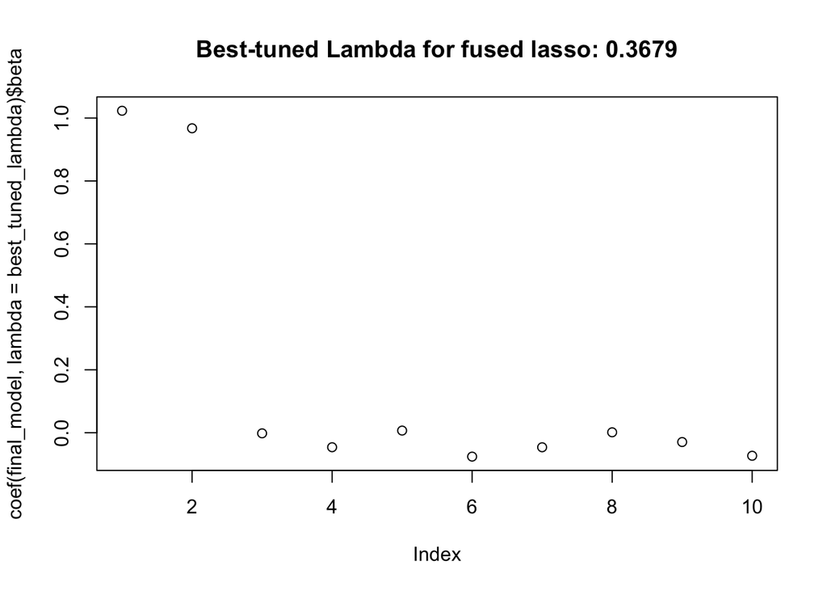

```r
# retreive final model
final_model <- check_caret$finalModel

# best-tuned parameter
best_tuned_lambda <- check_caret$bestTune$lambda

# retreive the beta coefficients
plot(coef(final_model, lambda = best_tuned_lambda)$beta,
     main = paste("Best-tuned Lambda for fused lasso:", round(best_tuned_lambda, 4)))
```

Ok it looks alright.

## 4.6 Compare results

### 4.6.1 RMSE

To make sure `caret` is behaving okay I compare the RMSE given in `caret` with what I get when I do the calculation by hand.

```r
caret_rmse <- check_caret$results %>%
  as.data.frame(.) %>%
  dplyr::select(gamma, lambda, RMSE)

difference <- left_join(caret_rmse, by_hand_fit, by = c("gamma", "lambda")) %>%
  mutate(abs_diff = abs(RMSE.x - RMSE.y))

# 25 zero's because there are 5 gammas and 5 lambdas (hence 25 combinations)
difference$abs_diff
```

```
##  [1] 0 0 0 0 0 0 0 0 0 0 0 0 0 0 0 0 0 0 0 0 0 0 0 0 0
```

So it seems that it’s working ok!

### 4.6.2 Time

And it seems `caret` is no faster than doing it by hand but much cleaner code I think.

```r
cat("Caret:", caret_speed, "\n")
```

```
## Caret: 2.799499
```

```r
cat("By hand:", by_hand_speed)
```

```
## By hand: 2.717948
```